# Portfolio Sorts in R

David McClelland

31/08/2020

# Preamble

Many investment topics require that you test investment strategies (momentum, size, value, long term reversal etc…), which means you should be familiar with a bottom up process for having full control over your portfolio sorting. That’s what this lesson is designed to help with

There are many packages out there that can provide some short-cuts for some of the more generic strategies but as Finance post-grad students, you should be able to customise strategies as much as you’d like. This script is a great starting point for gaining that knowledge.

I have made the script easily adjustable to bigger portfolios and longer time periods so you can see the effects of N and T on your research.

Lastly, this is a work in progress so it doesn’t yet cover everything. In particular, I would still like to add “dealing with missing data and data filters” as well as “optimisation and weighting strategies” but that is for another time.

# Load any required libraries

```r
# install.packages("RQuantLib")
library(tidyverse)                   # General data handling and graphs
library(lubridate)                   # Dealing with dates
library(RQuantLib)                   # Getting the South African Calendar
library(zoo)                         # rollapply function when creating portfolio returns
library(sjPlot)                      # Tabulating regression results
```

We also need to set a seed so that you can replicate what I’ve done and get the same answers in each step.

```r
set.seed(12345)
```

# Reproducible data

First we need to set up the data. I am going to simulate some plausible data for shares and the market here. I will assume we are working with daily data and I will simulate a year of data (I will use 2019 actual trading business days which happens to be 250 days)

```r
N = 10                                          # Number of shares in my sample

Date <- seq(ymd("2019-01-01"),ymd("2019-12-31"), by = "days")

df_returns <- data.frame(Date = Date[isBusinessDay("SouthAfrica", Date)])

Len <- nrow(df_returns)                          # Number of days in my sample

Share_Names <- paste0("Share_", 1:N)

Betas <- seq(0, 2, 2/(N-1))                      # Sets the betas to gradually increase

Alphas <- seq(0.0005, -0.0005, -0.001/(N-1))     # Sets the alphas to gradually decrease

df_returns <- df_returns %>%
  mutate(Market = rnorm(Len, mean = 0.001, sd = 0.01))

simulated_share_data <- matrix(data = mapply(function(a, b){a + df_returns$Market * b}, Alphas, Betas) + replicate(N, {rnorm(Len, mean = 0, sd = 0.016)}), ncol = N, byrow = F)

df_returns <- cbind(df_returns, simulated_share_data)

names(df_returns)[-c(1:2)] <- Share_Names
```

The first 5 rows and columns look as follows:

```r
df_returns[1:5, 1:5]
```

```
        Date     Market   Share_1   Share_2   Share_3
1 2019-01-02  6.855e-03 -0.012439 -0.020813  0.010713
2 2019-01-03  8.095e-03  0.016518 -0.037283  0.005431
3 2019-01-04 -9.303e-05  0.007797  0.008124  0.011053
4 2019-01-07 -3.535e-03 -0.022448 -0.015404 -0.013274
5 2019-01-08  7.059e-03 -0.003745  0.055249  0.019824
```

Great, now we have some reproducible data to work with. Next we need to come up with a strategy. Let’s assume empirical studies in other countries have shown that Low beta outperforms high beta shares on a risk adjusted basis (CAPM). Let’s see if this is true.

# Visualisation of the process

I’m going to visually show what each period is used for:

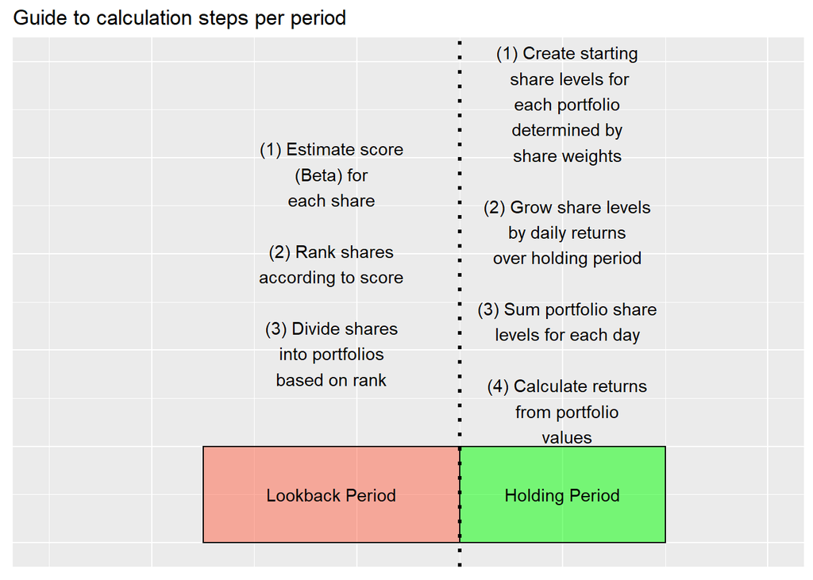

First step would be to define lookback and holding periods. Because we only have 250 days (determined by Len), let’s work with a 42 day lookback period (estimation) and a 21 day holding period.

We can define our number of periods based off of this. All we are doing here is determining how many full periods we can get by taking the total number of days in our sample (Len = 250), and then subtracting the first lookback period (because this data can’t be used in any holding period). We then divide by the number of days used in each holding period and finally we use “trunc()” to round down that number (so 9.9 becomes 9 because we can’t use 0.9 of a holding period).

```r
Lookback <- 42
Holding <- 21
Periods <- trunc((Len - Lookback)/Holding)
Periods
```

```
[1] 9
```

Now we can plot this portfolio rebalance scheme to get a good intuitive idea of what we are doing.

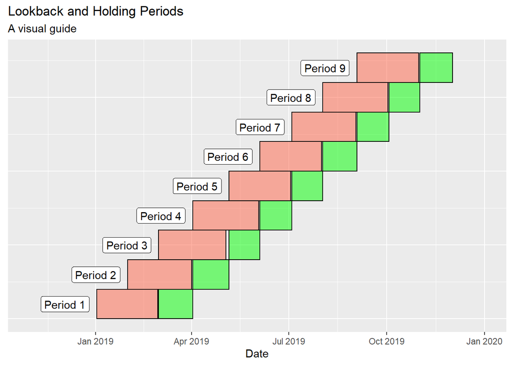

The gaps between the Lookback and the holding periods in our plot above are weekends and public holidays.

Note that we don’t use all of our data and the last few days at the end of the sample is not used at all. This is because we only have 9 full periods which uses an initial lookback period of 42 days as well as 9 holding periods of 21 days which is a total of 231 days. But our sample is 250 days which shows that we are not using the most recent 19 days. This is because we have a fixed starting point (1 January) and not a fixed end point (31st December). We could have also decided to make sure we use the most recent data and then missed out on the first 19 days of the year but used all the most recent data.

Now all we need to do is repeat the steps shown in the plot “Guide to calculation steps per period” for each period. We can make this easier by splitting our data into a list with length equal to the number of periods. So in our case, we can divide our data into 9 periods.

# Preparing and aligning lists

To do this using a general solution (will work no matter the size of your data), we can use a for loop and select rows based on whether we are looking at a lookback period or a holding period. Use the above plot to help see what we are doing in this step.

```r
lookback_list <- vector(mode = "list", length = Periods)
holding_list <- vector(mode = "list", length = Periods)

for(x in 1:Periods){
  lookback_list[[x]] = df_returns[(1+((x-1)*Holding)):(Lookback+((x-1)*Holding)), ]
  holding_list[[x]] = df_returns[(Lookback+1+((x-1)*Holding)):(Lookback+Holding+((x-1)*Holding)), ]
}
```

We can check if we’ve made a mistake here by looking at the first three dates that we would expect the lookback and holding period to start and end on.

We would expect the lookback period to start of the **1st day** and end 41 days later on **day 42** (42 days including the start and end date), the following period should start on **day 22** (we move in forward by one holding period - see the plot above to make clarify) and end on **day 63** (41 days later). Lastly by the same logic we should expect the third period to start on **day 43** and end on **day 84**.

To find the dates that correspond with those days:

```r
df_returns$Date[c(1, 42)]
```

```
[1] "2019-01-02" "2019-02-28"
```

```r
df_returns$Date[c(22, 63)]
```

```
[1] "2019-01-31" "2019-04-01"
```

```r
df_returns$Date[c(43, 84)]
```

```
[1] "2019-03-01" "2019-05-03"
```

Lets check that against our first three list element first and last days (“head” shows the first element from the start, “tail” shows the last element from the end)

```r
c(head(lookback_list[[1]]$Date, 1), tail(lookback_list[[1]]$Date, 1))
```

```
[1] "2019-01-02" "2019-02-28"
```

```r
c(head(lookback_list[[2]]$Date, 1), tail(lookback_list[[2]]$Date, 1))
```

```
[1] "2019-01-31" "2019-04-01"
```

```r
c(head(lookback_list[[3]]$Date, 1), tail(lookback_list[[3]]$Date, 1))
```

```
[1] "2019-03-01" "2019-05-03"
```

Now we have organised our data into corresponding lists. So the portfolios sorts and weights we generate out of “lookback_list[[1]]” should be used in the calculation of portfolio returns in “holding_list[[1]]” etc…

Let’s get started with our the first of our three steps that we need to go through with our lookback data.

# Lookback Period

1. **Estimate score (Beta) for each share**

We are trying to find out if low beta shares outperform high beta shares. So our score is the beta, or the coefficient from an OLS regression against the market.

We can start by working out a single beta estimate and then see how we can generalise and vectorise the process.

our beta estimate for Share_1 would be:

```r
lm(Share_1 ~ Market, lookback_list[[1]])$coefficients[2]
```

```
Market
0.2214
```

We are only interested in the coefficients of the regression and because we included an intercept term, the beta coefficient is the 2nd coefficient. To exclude the intercept term we would add a -1 to the regression.

```r
lm(Share_1 ~ Market - 1, lookback_list[[1]])$coefficients[1]
```

```
Market
0.1838
```

Let’s use the fact that dataframes can be seen as a list of vectors or as a two dimensional object. It’s very easy to use an lapply type function here to apply our above regression to every share in our sample.

“sapply” is identical to “lapply” but it returns a vector instead of a list.

We exclude the first two columns “[-c(1:2)]” because that is the “Date” and “Market” column. which we don’t want to apply the regression to.

```r
betas <- sapply(lookback_list[[1]][-c(1:2)], function(y){
  ans = lm(y ~ lookback_list[[1]]$Market - 1)$coefficients[1]
  names(ans) = names(y)
  return(ans)
})
betas
```

```
 Share_1  Share_2  Share_3  Share_4  Share_5  Share_6  Share_7  Share_8
  0.1838   0.3096   0.6213   0.8275   0.7356   1.1754   1.1566   1.8672
 Share_9 Share_10
  1.4322   1.8778
```

Let’s move onto our next step:

2. **Rank shares according to score**

Now that we have our results stored in an object called “betas”, we can rank our shares according to their score.

```r
beta_rank <- rank(betas)
beta_rank
```

```
 Share_1  Share_2  Share_3  Share_4  Share_5  Share_6  Share_7  Share_8
       1        2        3        5        4        7        6        9
 Share_9 Share_10
       8       10
```

“rank” by default ranks their score from lowest to highest. If you instead wanted the ranking to be in descending order (1 = highest score), then you would simply add a negative value before the “betas”.

```r
beta_rank <- rank(-betas)
```

We will be using the first method going forward.

Great, that was nice and easy.

3. **Divide shares into portfolios based on rank**

We could use this result directly with our “holding_list” data but I want to keep our steps clear and distinct. Here we will take our ranks and form portfolios.

We haven’t yet made a portfolio rule for sorting portfolio so let’s add another rule to our rule set. Let’s use the rule that the **bottom 30% is portfolio 1**, the **middle 40% is portfolio 2** and the **top 30% is portfolio 3**.

That means our hypothesis is that portfolio 1 alpha (low beta) > portfolio 3 alpha (high beta).

We need to be careful here because 30% of a portfolio isn’t always a whole number. So our rules need to be carefully explained and thought through.  
You may want to make your rule something like “portfolio 1 is the rounded up lowest 30% and the portfolio 3 is the rounded up highest 30% and portfolio 2 is everything else”.  
That would ensure that portfolio 1 and 3 (our portfolios of interest for our hypothesis) always have the same number of shares. Another method that may make things easier is to filter your shares at each period to always have the same number of shares (top 100 by market cap etc…), that way if you are using quintiles you will always have 20 shares per portfolio and if you are using terciles your breakdown can be made consistent (33 shares in portfolio 1, 34 shares in portfolio 2 and 33 shares in portfolio 3) because you don’t have to rely on percentiles.

If we want the share names to be in the order of their beta score we can simply add the beta_rank as an index value to their names vector

```r
names(beta_rank)[beta_rank]
```

```
 [1] "Share_1"  "Share_2"  "Share_3"  "Share_5"  "Share_4"  "Share_7"
 [7] "Share_6"  "Share_9"  "Share_8"  "Share_10"
```

Now we can easily form portfolios by using our portfolio break point rule (We are using the rule that keeps the high and low portfolios with the same number of stocks):

```r
portfolio_names_1 = names(beta_rank)[beta_rank][1:3]
portfolio_names_2 = names(beta_rank)[beta_rank][4:7]
portfolio_names_3 = names(beta_rank)[beta_rank][8:10]
```

Note that we can edit this to apply to any of the suggestions in italics above.

Our portfolios now look as follows for period 1:

```r
portfolio_names_1
```

```
[1] "Share_1" "Share_2" "Share_3"
```

```r
portfolio_names_2
```

```
[1] "Share_5" "Share_4" "Share_7" "Share_6"
```

```r
portfolio_names_3
```

```
[1] "Share_9"  "Share_8"  "Share_10"
```

Now that we have completed all of the steps for lookback for one period, we can generalise the process. Before we do this, let’s first create an object to store our output. All we need from this is the names of the shares in each portfolio.

```r
portfolio_names <- vector(mode = "list", length = Periods)
```

## Generalised lookback period calculations

Now we can generlise the procedure and solve for all of our periods.

```r
number_of_portfolios = 3

quantile = trunc(N/number_of_portfolios)

portfolio_names <- lapply(lookback_list, function(z){
  betas = sapply(z[-c(1:2)], function(y){
    ans = lm(y ~ z$Market - 1)$coefficients[1]
    names(ans) = names(y)
    return(ans)
  })
  beta_rank = rank(betas)

  return(list(portfolio_1 = names(beta_rank)[beta_rank][1:quantile],
              portfolio_2 = names(beta_rank)[beta_rank][(quantile+1):(N-quantile)],
              portfolio_3 = names(beta_rank)[beta_rank][(N-quantile+1):(N)]))
})
```

Let’s look at what the portfolios look like for our 1st and 5th period:

```r
portfolio_names[[1]]
```

```
$portfolio_1
[1] "Share_1" "Share_2" "Share_3"

$portfolio_2
[1] "Share_5" "Share_4" "Share_7" "Share_6"

$portfolio_3
[1] "Share_9"  "Share_8"  "Share_10"
```

```r
portfolio_names[[5]]
```

```
$portfolio_1
[1] "Share_2" "Share_1" "Share_3"

$portfolio_2
[1] "Share_4" "Share_5" "Share_6" "Share_7"

$portfolio_3
[1] "Share_10" "Share_9"  "Share_8"
```

We know that’s correct for the first period but let’s check if that’s correct for the 5th period:

```r
betas <- sapply(lookback_list[[5]][-c(1:2)], function(y){
  ans = lm(y ~ lookback_list[[5]]$Market - 1)$coefficients[1]
  names(ans) = names(y)
  return(ans)
})
betas
```

```
 Share_1  Share_2  Share_3  Share_4  Share_5  Share_6  Share_7  Share_8
  0.4497   0.2951   0.5663   0.7188   1.0295   1.2597   1.5597   1.8577
 Share_9 Share_10
  1.8356   1.7110
```

OK great, based on our quick checks, everything looks like it’s working as expected.

Now we can take our lookback results and use them to complete our holding period checklist.

# Holding Period

1. **Create starting share levels for each portfolio determined by share weights**

Here you need to consult an additional rule that we haven’t yet decided on. How do we weight the shares that make it into each portfolio once they’ve been selected?

To make matter simple, we will assume we are interest in equal weighting. That means we can just start our portfolio levels off as all = 1.

Once again we will work out the solution for one portfolio in one period and then generalise.

First, select only the shares that should be in portfolio 1 in period 1

```r
port_1 = holding_list[[1]][ ,portfolio_names[[1]]$portfolio_1]

head(port_1)
```

```
     Share_1    Share_2   Share_3
43 -0.002546 -0.0001649  0.009940
44  0.006898  0.0332597 -0.005151
45 -0.015146  0.0284532  0.011491
46  0.003440  0.0373463  0.011045
47 -0.033905 -0.0136049 -0.025656
48 -0.009467 -0.0347232  0.006821
```

We know our next step would be to grow our each share from their starting level by (1 + return) for each day in the holding period.

Because our starting level is 1 (because we are equally weighting our portfolios) this first step isn’t as necessary but it’s good to set up in case we need to use different weighting scheme next time. We add a starting value to the beginning of this series to represent the starting weights.

we can simply add 1 to all of our values and then multiply them together in a rolling window (level1 = (1+return1), level2 = (level1*(1+return2)), etc…)

```r
starting_weights = rep(1, length(port_1))
```

2. **Grow share levels by daily returns over holding period**

We can simply add 1 to all of our values and then multiply them together in a rolling window (level1 = (1+return1), level2 = (level1*(1+return2)), etc…)

```r
level_1 <- rbind(starting_weights, port_1 + 1)
level_1 <- rollapply(level_1, FUN = prod, width = 1:(Holding+1), align = "right")
level_1[1:5, ]
```

```
     Share_1 Share_2 Share_3
[1,]  1.0000  1.0000   1.000
[2,]  0.9975  0.9998   1.010
[3,]  1.0043  1.0331   1.005
[4,]  0.9891  1.0625   1.016
[5,]  0.9925  1.1022   1.028
```

3. **Sum portfolio share levels for each day**

Now we can simply add up all of the share levels for each day to get a portfolio value. The starting value will just be equal to the sum of the starting weights (in our case 1+1+1)

```r
value_1 <- rowSums(level_1)
length(value_1)
```

```
[1] 22
```

```r
value_1[1:5]
```

```
[1] 3.000 3.007 3.042 3.068 3.122
```

As you can see above, the length of value_1 is now 1 longer than our holding period. This is because we added a starting value. The length goes back to the length of our holding period once we calculate returns because we lose an observation when calculating returns.

4. **Calculate returns from portfolio values**

To solve for the portfolio returns, we simply use the vectorised version of the arithmetic formula (new - old)/old

```r
returns_1 = (value_1[-1] - value_1[-length(value_1)])/value_1[-length(value_1)]
returns_1
```

```
 [1]  0.002410  0.011616  0.008458  0.017702 -0.024024 -0.013127 -0.008472
 [8]  0.014679 -0.005116  0.003556  0.003108  0.017442  0.008829  0.019088
[15]  0.008233  0.001872  0.013810  0.002496 -0.007071 -0.001155  0.003066
```

## Generalised holding period calculations

Now that we have solved our holding period calculations for one period for one portfolio, we can solve it for all time periods.

Instead of writing our function inside of our “lapply” like we did earlier, let’s write our function first. That way we can use it for each portfolio.

```r
hld_period_calcs <- function(a, b, weights = 1, port_number){
  port = a[ ,b[[port_number]]]
  starting_weights = rep(weights, length(port))
  level = rbind(starting_weights, port + 1)
  level = rollapply(level, FUN = prod, width = 1:(Holding+1), align = "right")
  value = rowSums(level)
  returns = (value[-1] - value[-length(value)])/value[-length(value)]
  return(returns)
}
```

Now we can use this function to create all three of our portfolios

```r
portfolio_df <- data.frame(Dates = df_returns$Date[-c(1:Lookback)][1:(Periods*Holding)],
                           Market = df_returns$Market[-c(1:Lookback)][1:(Periods*Holding)],
                           Low_Beta = unlist(Map(hld_period_calcs, holding_list, portfolio_names, port_number = 1)),
                           Medium_Beta = unlist(Map(hld_period_calcs, holding_list, portfolio_names, port_number = 2)),
                           High_Beta = unlist(Map(hld_period_calcs, holding_list, portfolio_names, port_number = 3)))

head(portfolio_df)
```

```
       Dates    Market  Low_Beta Medium_Beta High_Beta
1 2019-03-01 -0.009603  0.002410   -0.009820  -0.01905
2 2019-03-04  0.010371  0.011616    0.011022   0.02621
3 2019-03-05  0.009545  0.008458    0.003475   0.02315
4 2019-03-06  0.015607  0.017702    0.019766   0.01258
5 2019-03-07 -0.013131 -0.024024   -0.018690  -0.01707
6 2019-03-08  0.006674 -0.013127   -0.001890   0.02483
```

# Plotting our results and running our model

It’s often useful to plot your portfolio results from a starting investment of R1 to see how well they would have performed. To do this we use our “rollapply” function from before and add it to our dataframe using “mutate”

```r
portfolio_df <- portfolio_df %>%
  mutate(Low_Beta_level = rollapply((1 + Low_Beta), FUN = prod, width = 1:nrow(portfolio_df), align = "right"),
         Medium_Beta_level = rollapply((1 + Medium_Beta), FUN = prod, width = 1:nrow(portfolio_df), align = "right"),
         High_Beta_level = rollapply((1 + High_Beta), FUN = prod, width = 1:nrow(portfolio_df), align = "right"))
```

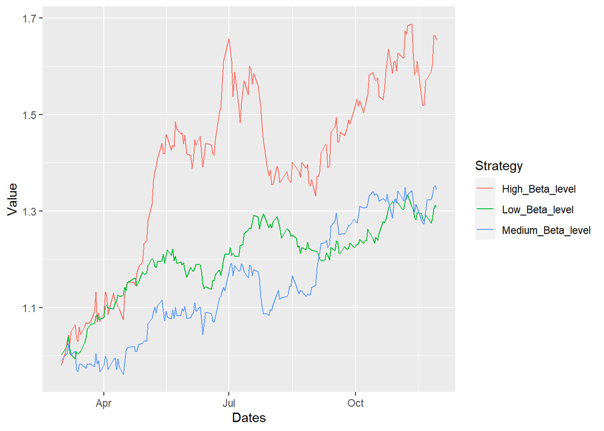

```r
plot_df <- portfolio_df %>%
  select(Dates, Low_Beta_level, Medium_Beta_level, High_Beta_level) %>%
  gather(key = "Strategy", value = "Value", -1)

ggplot(plot_df, aes(x = Dates, y = Value, colour = Strategy))+
  geom_line()
```

You may think the results don’t show any low beta effect but you’ll notice that although the returns are approximately equal to the medium Beta portfolio, the risk of the medium and high beta portfolio is substantially higher.

Let’s run our regression model which would test the significance of the Low-High Beta intercept term.

```r
portfolio_df <- portfolio_df %>%
  mutate(Low_Minus_High_Beta = Low_Beta - High_Beta)

model_1 <- lm(Low_Beta ~ Market, portfolio_df)
model_2 <- lm(Medium_Beta ~ Market, portfolio_df)
model_3 <- lm(High_Beta ~ Market, portfolio_df)
model_4 <- lm(Low_Minus_High_Beta ~ Market, portfolio_df)

tab_model(model_1, model_2, model_3, model_4, show.ci = F, digits = 4, digits.p = 4)
```

|  | Low_Beta |  | Medium_Beta |  | High_Beta |  | Low_Minus_High_Beta |  |
| --- | --- | --- | --- | --- | --- | --- | --- | --- |
| Predictors | Estimates | p | Estimates | p | Estimates | p | Estimates | p |
| (Intercept) | 0.0009 | 0.1990 | -0.0006 | 0.3685 | -0.0007 | 0.2563 | 0.0016 | 0.0896 |
| Market | 0.2775 | **<0.001** | 1.0655 | **<0.001** | 1.7060 | **<0.001** | -1.4285 | **<0.001** |
| Observations | 189 |  | 189 |  | 189 |  | 189 |  |
| R<sup>2</sup> / R<sup>2</sup> adjusted | 0.090 / 0.085 |  | 0.653 / 0.652 |  | 0.834 / 0.833 |  | 0.597 / 0.594 |  |

You can see that despite the fact that this data is simulated to have a low beta effect, it is not significant at the 5% level (Low_Minus_High_Beta intercept term). In fact, none of the intercept terms are significant. The rest of the results seem to line up with expectations and the ex-post beta results reflect the sorting criteria (low beta sorted portfolio have a beta of approx. 0.28 and the high beta portfolio is approx. 1.7).

The reason our results aren’t significant is because our sample period is too short and our sample size is too small to pick up the effect. Try changing the starting date from “2019-01-01” (1 year sample) to “2016-01-01” (4 year sample) and changing N from 10 to 100 and see the results.

Remember this when designing research!